# 01-Introducción y repaso

## Introducción

En este curso nos interesa entender y describir patrones de dependencia de un conjunto de variables aleatorias. Consideraremos algunas de las herramientas más populares que se usan para este fin:

- Redes markovianas (modelos gráficos no dirigidos), modelos gráficos gaussianos, modelos loglineales.
- Redes bayesianas (modelos gráficos dirigidos).
- Análisis de factores, clases latentes, clustering.
- Modelos de dependencia espacial y temporal.
- Regresión para datos agrupados o jerárquicos (extensión de GLMs).

Por ejemplo:

- En estadística espacial nos interesa entender y modelar qué variables están asociadas por contiguidad. Por ejemplo: variables de estaciones de medición metereológica, ambiental, ocurrencias de crimen en una ciudad, etc.
- Series de tiempo, secuencias de observaciones ordenadas cronológicamente.
- En el estudio de factores relacionados con una enfermedad, muchas veces no solamente nos interesa la predicción de quién está en riesgo (por ejemplo, probabilidad de cáncer de pulmón), sino también como se asocian hábitos negativos, predisposiciones y otros factores de riesgo. Por ejemplo: ¿qué niveles socioeconómicos fuman más o menos? ¿a través de que hábitos o factores los niveles socioeconómicos más bajos tienen mayor riesgo?
- En medición de logro académico, ¿qué tanto de las calificaciones de los alumnos se deben a la escuela (asociación entre calificaciones a nivel de escuela) y qué tanto a la habilidad de los alumnos que están en esa escuela?
- Variable latente, por ejemplo datos faltantes.

Veremos métodos que se clasifican como no supervisados en el sentido de que no queremos predecir ninguna variable particular, y métodos supervisados (en los cuales nos enfocamos en entender las dependencias de una sola variable respuesta de otras entradas, como en machine learning o modelos lineales generalizados).

En los primeros temas (modelos gráficos) buscaremos herramientas para expresar patrones de dependencia complejos (más allá de covarianzas o correlaciones simples, por ejemplo) entre varias variables aleatorias. Los últimos tres temas se refieren a herramientas que se utilizan en contextos más concretos: variables latentes, datos espacio-temporales, y datos agrupados en jerarquías.

### Patrones complejos de dependencia

Cuando consideramos dos variables aleatorias, tenemos herramientas simples para describir dependencia:

Por ejemplo, para dos variables numéricas, podemos usar correlaciones. En este ejemplo, rendimiento de coches y cilindros están negativamente correlacionadas:

```r
library(ggplot2)
cor(mpg[,c('cyl','cty')])
```

```
##            cyl        cty
## cyl  1.0000000 -0.8057714
## cty -0.8057714  1.0000000
```

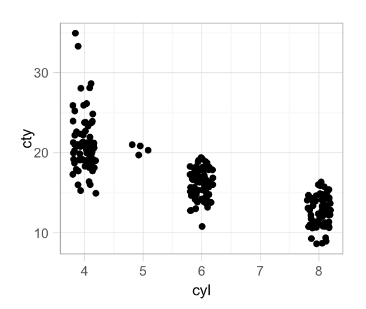

```r
ggplot(mpg, aes(x=cyl, y=cty)) +
  geom_jitter(position=position_jitter(width=0.2))
```

Para variables categóricas podemos usar tablas para entender cómo está relacionada la transmisión y el tipo de coche,

```r
table(mpg$class, mpg$drv)
```

```
##
##               4  f  r
##   2seater     0  0  5
##   compact    12 35  0
##   midsize     3 38  0
##   minivan     0 11  0
##   pickup     33  0  0
##   subcompact  4 22  9
##   suv        51  0 11
```

podemos calcular las distribuciones condicionales empíricas dado el tipo de coche:

```r
round(100*prop.table(table(mpg$class, mpg$drv), margin=1))
```

```
##
##                4   f   r
##   2seater      0   0 100
##   compact     26  74   0
##   midsize      7  93   0
##   minivan      0 100   0
##   pickup     100   0   0
##   subcompact  11  63  26
##   suv         82   0  18
```

O podemos sacar las condicionales empíricas dado el tipo de transmición:

```r
round(100*prop.table(table(mpg$class, mpg$drv), margin=2))
```

```
##
##               4  f  r
##   2seater     0  0 20
##   compact    12 33  0
##   midsize     3 36  0
##   minivan     0 10  0
##   pickup     32  0  0
##   subcompact  4 21 36
##   suv        50  0 44
```

Sin embargo, cuando tenemos más de dos variables, los patrones de asociación tienen más riqueza. Como ejemplo, pensemos en un problema ficticio, con tres variables binarias: si el jardín está mojado o no, si llovió o no llovió, y si el jardín fue o no regado. Vemos que regar el jardín no está relacionado con que llueva o no:

```r
load('datos/lluvia.Rdata')
table(lluvia$lluvia, lluvia$regar)
```

```
##
##       0   1
##   0 394  76
##   1 107  23
```

```r
prop.table(table(lluvia$lluvia, lluvia$regar), margin = 1)
```

```
##
##             0         1
##   0 0.8382979 0.1617021
##   1 0.8230769 0.1769231
```

Pero si condiconamos a que el pasto está mojado, entonces lluvia y regar están inversamente correlacionados, un ejemplo de porque ocurre es que si el suelo está mojado y no hay lluvia entonces se regó el jardín,

```r
table(lluvia$lluvia, lluvia$regar, lluvia$mojado)
```

```
## , ,  = FALSE
##
##
##       0   1
##   0 394   0
##   1   0   0
##
## , ,  = TRUE
##
##
##       0   1
##   0   0  76
##   1 107  23
```

```r
prop.table(table(lluvia$lluvia, lluvia$regar, lluvia$mojado), margin = c(1, 3))
```

```
## , ,  = FALSE
##
##
##             0         1
##   0 1.0000000 0.0000000
##   1
##
## , ,  = TRUE
##
##
##             0         1
##   0 0.0000000 1.0000000
##   1 0.8230769 0.1769231
```

Otro ejemplo de dependencia, tomado de Gelman, es un análisis de votantes en Estados Unidos, votantes más ricos tienden a votar más por el partido republicano. Sin embargo, estados más ricos tienden a votar más por demócratas. La relación de dependencia se ve en distintas direcciones dependiendo del nivel que lo veamos (estado o individuo):

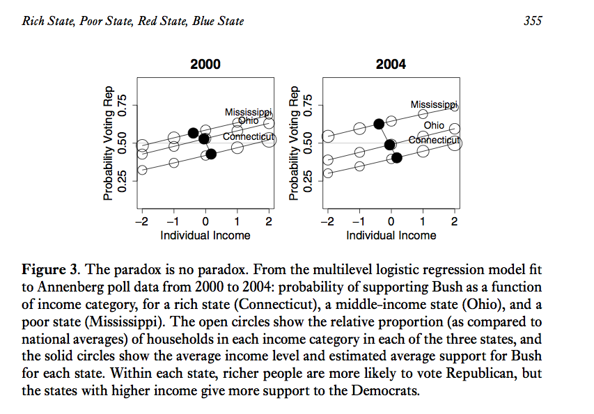

### Modelos gráficos

Un modelo gráfico es una red de variables aleatorias donde:

- Nodos representan variables aleatorias.
- Arcos (dirigidos o no) representan dependencia

Los dos esquemas generales para representar dependencias/independiencias (condicionales) de forma gráfica son los modelos dirigidos (redes bayesianas) y no dirigidos (redes markovianas).

Veamos un ejemplo de un modelo gráfico **no dirigido**.

Consideramos las calificaciones de 88 alumnos (Mardia 1979) en cinco áreas: vectores (VECT), mecánica (MECH), álgebra (ALG), análisis (ANL) y estadística (STAT)). Podemos representar la estrucutra de covarianza con una gráfica como la siguiente:

```r
library(bnlearn)
data(marks)
head(marks)
```

```
##   MECH VECT ALG ANL STAT
## 1   77   82  67  67   81
## 2   63   78  80  70   81
## 3   75   73  71  66   81
## 4   55   72  63  70   68
## 5   63   63  65  70   63
## 6   53   61  72  64   73
```

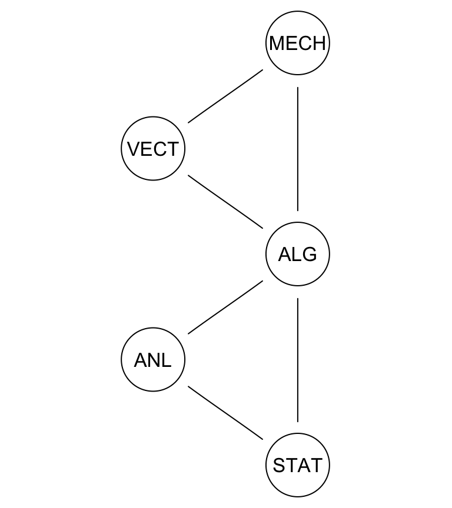

```r
library(ggplot2)
library(Hmisc)
marks.graph <- gs(marks)
graphviz.plot(marks.graph)
```

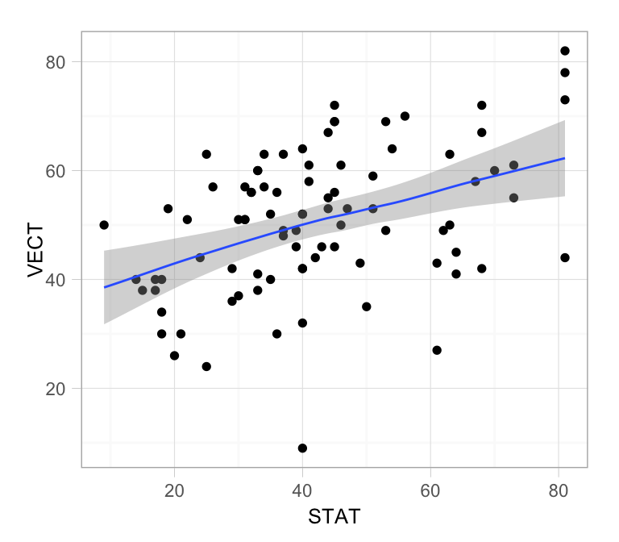

```r
ggplot(marks, aes(x = STAT, y = VECT)) +
  geom_point() +
  geom_smooth(span=1, method='loess', degree=1)
```

Pero también sugiere que **dada la calificación de álgebra**, estadística y vectores no están correlacionados:

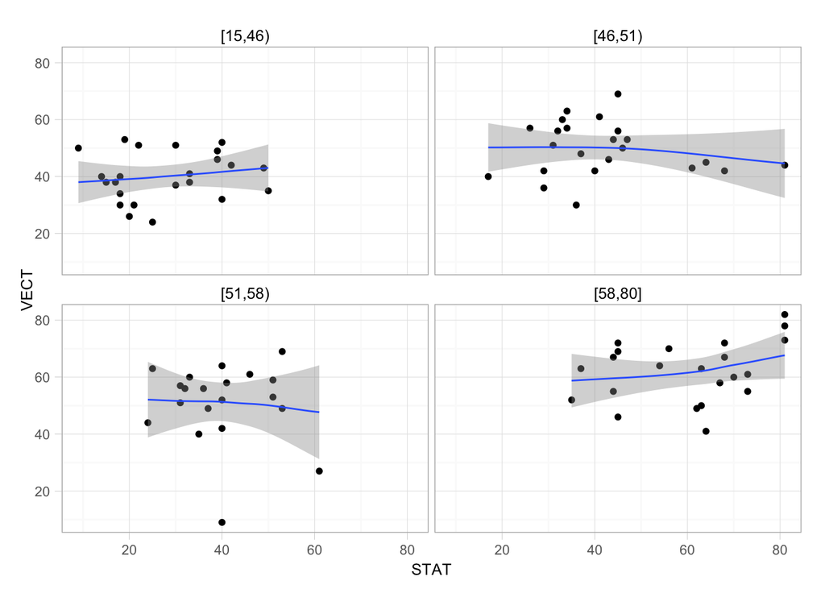

```r
marks$ALG_grupos <- cut2(marks$ALG, g=4)
ggplot(marks, aes(x=STAT, y=VECT)) + facet_wrap(~ALG_grupos) + geom_point() +
  geom_smooth(span=2, method='loess', degree=1)
```

Lo cual no sucede por ejemplo, si estudiamos la asociación entre STAT y ANL condicionando a ALG:

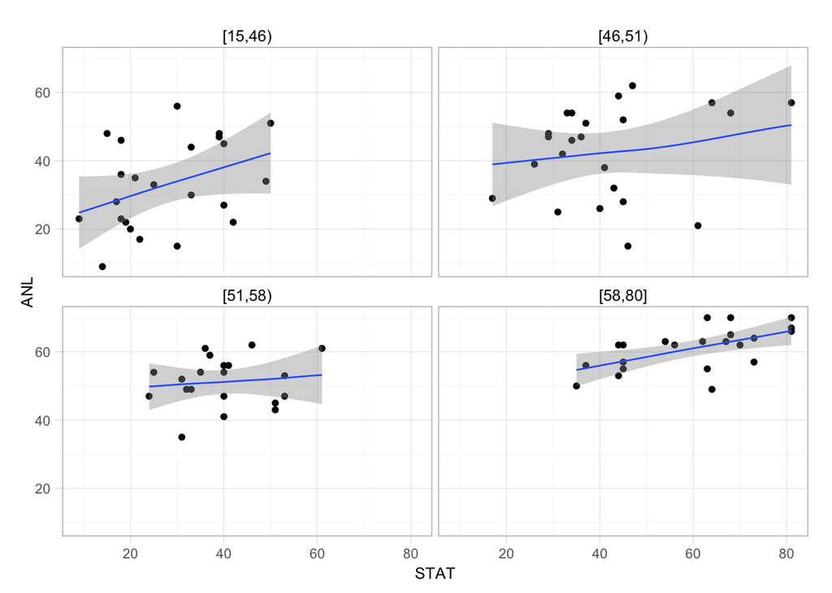

```r
ggplot(marks, aes(x=STAT, y=ANL)) + facet_wrap(~ALG_grupos) + geom_point() +
  geom_smooth(span=2, method='loess', degree=1)
```

En la red que representa la estructura de dependencia de estos datos, el hecho de que ALG separa a VECT de STAT se interpreta como sigue: si hacemos una regresión de STAT en función de VECT, controlando por ALG, el coeficiente de VECT es 0.

Del modelo gráfico obtenemos varias simplificaciones (Whittaker):

- Podemos entender la estructura de estos datos analizando dos grupos de tres variables cada uno, en lugar de intentar un análisis conjunto de las 5 variables.
- Estamos en una mejor posición para modelar este problema: en un principio, estábamos en el punto de “todo se relaciona con todo”, y esto implica un modelo muy grande y complejo. Modelos tan grandes muchas veces son imposibles de tratar con cualquier conjunto de datos de tamaño usual. Las independiencias condicionales que acabamos de establecer simplifican considerablemente el tipo de modelos que debemos considerar.
- Si quisiéramos predecir estadística (EST), por ejemplo, basta con usar álgebra y análisis. Esto puede permitirnos construir mejores modelos y más fáciles de entender.
- Descubrimos que en un sentido al examen de álgebra es el más importante, pues podría fundamentar todas las demás. Por otra parte, también aprendimos que hay potencialmente dos habilidades adicionales al álgebra que están asociadas a VECT y MECH por un lado, y a STAT y ANL por otro.

Como ejemplo de **modelos dirigidos** veremos una red de seguros de auto.

En este ejemplo nos interesa entender los patrones de dependencia entre variables como edad, calidad de conductor y tipo de accidente:

```r
library(bnlearn)
head(insurance)
```

```
##   GoodStudent        Age   SocioEcon RiskAversion VehicleYear ThisCarDam
## 1       False      Adult       Prole  Adventurous       Older   Moderate
## 2       False     Senior       Prole     Cautious     Current       None
## 3       False     Senior UpperMiddle   Psychopath     Current       None
## 4       False Adolescent      Middle       Normal       Older       None
## 5       False Adolescent       Prole       Normal       Older   Moderate
## 6       False      Adult UpperMiddle       Normal     Current   Moderate
##   RuggedAuto Accident   MakeModel DrivQuality    Mileage Antilock
## 1   EggShell     Mild     Economy        Poor TwentyThou    False
## 2   Football     None     Economy      Normal TwentyThou    False
## 3   Football     None FamilySedan   Excellent     Domino     True
## 4   EggShell     None     Economy      Normal  FiftyThou    False
## 5   Football Moderate     Economy        Poor  FiftyThou    False
## 6   EggShell Moderate   SportsCar        Poor  FiftyThou     True
##   DrivingSkill SeniorTrain ThisCarCost Theft   CarValue HomeBase AntiTheft
```

[output cut: 20 more lines]

```r
insurance_dat <- insurance[, c('Age', 'GoodStudent', 'SocioEcon', 'RiskAversion',
                               'Accident','DrivQuality')]
blacklist <- data.frame(from=c('DrivQuality','Accident'), to=c('Age','DrivQuality'))
```

Utilizamos una red bayesiana:

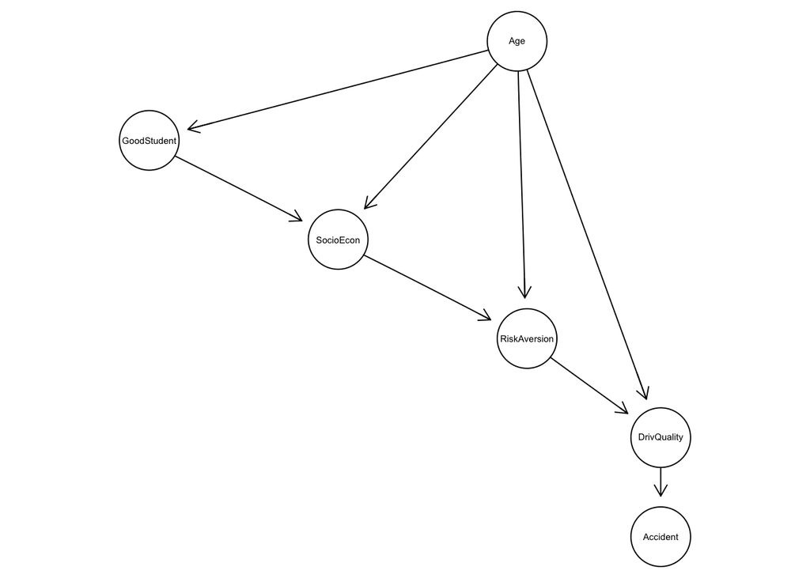

```r
insurance_gm <- hc(insurance_dat, blacklist = blacklist)
graphviz.plot(insurance_gm)
```

```r
insurance.fit <- bn.fit(insurance_gm, data = insurance_dat, method = 'bayes',
                        iss = 1)
#write.net(file = './salidas/insurance.net', insurance.fit)
```

¿Cómo interpretar esta gráfica? Vemos por ejemplo como mucho de la asociación entre edad y tipo de accidente desaparece cuando condicionamos a calidad de conductor.

```r
prop.table(table(insurance$Age, insurance$Accident), margin = 1)
```

```
##
##                    Mild   Moderate       None     Severe
##   Adolescent 0.12136878 0.11718365 0.57336288 0.18808469
##   Adult      0.08442918 0.07797973 0.73314348 0.10444761
##   Senior     0.05926482 0.04926232 0.81370343 0.07776944
```

```r
prop.table(table(insurance$Age, insurance$Accident, insurance$DrivQuality),
           margin = c(1, 3))
```

```
## , ,  = Excellent
##
##
##                     Mild    Moderate        None      Severe
##   Adolescent 0.011627907 0.001937984 0.982558140 0.003875969
##   Adult      0.011175899 0.004373178 0.981535471 0.002915452
##   Senior     0.004488330 0.003590664 0.988330341 0.003590664
##
## , ,  = Normal
##
##
##                     Mild    Moderate        None      Severe
##   Adolescent 0.016764459 0.013411567 0.961441744 0.008382230
##   Adult      0.022364771 0.011095700 0.960124827 0.006414702
##   Senior     0.025309917 0.013946281 0.955578512 0.005165289
##
## , ,  = Poor
##
##
##                     Mild    Moderate        None      Severe
##   Adolescent 0.198470038 0.195070123 0.286867828 0.319592010
##   Adult      0.208120593 0.208606856 0.290542183 0.292730367
##   Senior     0.192834563 0.174920969 0.319283456 0.312961012
```

También podemos entender cómo depende calidad de conductor de edad y aversión al riesgo (modelo local para DrvQuality):

```r
prop_tab_q <- prop.table(table(insurance$DrivQuality, insurance$RiskAversion,
                               insurance$Age), c(2, 3))
prop_tab_q
```

```
## , ,  = Adolescent
##
##
##             Adventurous   Cautious     Normal Psychopath
##   Excellent  0.18324079 0.16666667 0.04441703 0.21951220
##   Normal     0.17617365 0.35185185 0.43491672 0.07317073
##   Poor       0.64058556 0.48148148 0.52066626 0.70731707
##
## , ,  = Adult
##
##
##             Adventurous   Cautious     Normal Psychopath
##   Excellent  0.28822140 0.22950127 0.09635941 0.25161290
##   Normal     0.24130948 0.47041420 0.60712626 0.13548387
##   Poor       0.47046912 0.30008453 0.29651433 0.61290323
##
## , ,  = Senior
##
##
##             Adventurous   Cautious     Normal Psychopath
##   Excellent  0.25153374 0.37506065 0.15816327 0.25000000
##   Normal     0.18711656 0.49199418 0.54591837 0.11363636
##   Poor       0.56134969 0.13294517 0.29591837 0.63636364
```

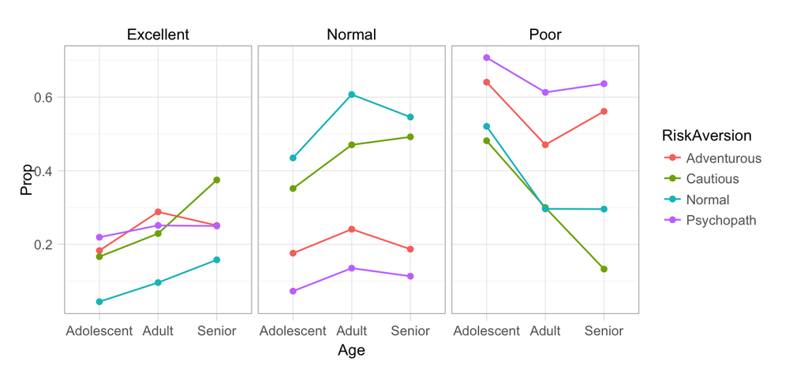

```r
df_q <- data.frame(prop_tab_q)
names(df_q) <- c('DrvQuality', 'RiskAversion', 'Age', 'Prop')
ggplot(df_q, aes(x = Age, y = Prop, colour = RiskAversion,
                 group = RiskAversion)) +
  geom_line() + facet_wrap(~DrvQuality) +
  geom_point()
```

Otras asociaciones con *DrvQuality* podemos entenderlas a través de estas dos variables: edad y aversión al riesgo. Veremos cómo modelar estas estructuras (además de usar las tablas, que corresponden a estimación de máxima verosimilitud sin restricciones, podemos usar por ejemplo GLMs).

### ¿Por qué modelos gráficos?

- Usando modelos gráficos podemos representar de manera compacta y atractiva distribuciones de probabilidad entre variables aleatorias.
- Auxiliar en el diseño de modelos.
- Fácil combinar información proveniente de los datos con conocimiento de expertos.
- Proveen un marco general para el estudio de modelos más específicos. Muchos de los modelos probabilísticos multivariados clásicos son casos particulares del formalismo general de modelos gráficos (mezclas gaussianas, modelos de espacio de estados ocultos, análisis de factores, filtro de Kalman,…).
- Juegan un papel importante en el diseño y análisis de algoritmos de aprendizaje máquina.

### Repaso de probabilidad

La **distribución conjunta** sobre un conjunto de variables aleatorias $\{X_1,...,X_n\}$, que denotamos $p(x_1,...,x_n)$, asigna probabilidades a todos los eventos determinados por el conjunto de variables aleatorias.

En el caso **discreto bivariado**, dado las variables aleatorias discretas $X$ y $Y$, definimos la función de densidad conjunta como $f(x,y)=P(X=x, Y=y)$.

En el caso **continuo bivariado**, decimos que la función $p(x,y)$ es una función de densidad de probabilidad para las variables aleatorias $(X,Y)$ si:

1. $p(x,y) \geq 0$ para toda $(x,y)$.
2. $\int_{-\infty}^{\infty}p(x,y)dxdy=1$.
3. Para cualquier conjunto $A \subset \mathbb{R} \times \mathbb{R}$, $P((X,Y) \in A) = \int\int_A p(x,y)dxdy$.

**Ejemplo.** Sean $(X,Y)$ uniformes en el cuadrado unitario, entonces $p(x,y) = \left\{ \begin{array}{lr} 1 & 0\leq x \leq 1,0\leq y \leq 1\\ 0 & e.o.c. \end{array} \right.$

Para encontrar $P(X < 1/2, Y<1/2)$, esto es la probailidad del evento $A=\{X<1/2, Y<1/2\}$. La integral de $p$ sobre este subconjunto corresponde, en este caso, a calcular el área del conjunto $A$ que es igual a 1/4.

De la distribución conjunta $p(x_1,...,x_n)$ podemos obtener la distribución de únciamente una variable aleatoria $X_j$, donde $X_j \in \{X_1,...,X_n\}$, la llamamos la distribución marginal de $X_j$.

Sea $\{X_1,...,X_n\}$ un conjunto de variables aleatorias con distribución conjunta $p(x_1,...,x_n)$, la **distribución marginal** de $X_j$ ($j \in \{1,...,n\}$) se define como, $p_{X_j}(x_j) = \sum_{x_1,...,x_{j-1},x_{j+1},...,x_n}p(x_1,...,x_n)\mbox{ en el caso discreto,}$ $p_{X_j}(x_j) = \int_{x_1,...,x_{j-1},x_{j+1},...,x_n}p(x_1,...,x_n)dx_1,...,dx_n\mbox{ en el caso continuo}$

**Ejemplo.** Retomando el problema de los departamentos, ¿Cuál es la probabilidad de que un departamento elegido al azar sea público?

### Probabilidad condicional

**Ejemplo.** ¿Cuál es la probabilidad de que un departamento privado tenga renta *baja*?  
¿Cómo se compara con la probabilidad de que la renta sea baja (desconozco el tipo de departamento)?

La noción de probabilidad condicional se extiende a distribuciones condicionales:

Sean $X$, $Y$ dos variables aleatorias con función de densidad conjunta $p(x,y)$, entonces la función de densidad condicional de $X$ dado $Y=y$, para toda $y$ tal que $p_Y(y) > 0$, se define como $p_{X\vert Y}(x\vert y) = \frac{p(x, y)}{p_Y(y).}$

### Probabilidad Total

Sean $E$, $F$ dos eventos entonces, $P(E) = P(E\vert F)P(F) + P(E\vert F^c)P(F^c).$ De manera más general, sean $F_i$ $i = 1,...,n$ eventos mutuamente excluyentes cuya unión es el espacio muestral, entonces $P(E) = \sum_{i=1}^n P(E\vert F_i)P(F_i).$

La identidad anterior nos dice que podemos expresar la probabilidad del evento $E$ como un promedio ponderado de probabilidades condicionales.

**Ejemplo.** Supongamos que una aseguradora clasifica a la gente en tres grupos de acuerdo a su nivel de riesgo: bajo, medio y alto. De acuerdo a los registros, las probabilidades de incurrir en un accidente en un laspo de un año son 0.05, 0.15 y 0.30 respectivamente. Si el 20% de la población se clasifica en riesgo bajo, 50% en medio y 30% en alto, ¿qué proporción de la población tiene un accidente en un año dado?

Para variables aleatorias tenemos:

Sean $X$, $Y$ dos variables aleatorias, podemos expresar la distribución marginal de $X$ como: $p_X(x) = \sum_{y} p_{X \vert Y}(x\vert y)p_Y(y).$

Supongamos que ruedo un dado, si observo un número par lanzo una moneda justa (la probabilidad de observar águila es la misma que la de observar sol), si el dado muestra un número impar lanzo una moneda sesgada en la que la probabilidad de observar águila es 0.9. Si observo sol, ¿Cuál es la probabilidad de que haya lanzado la moneda sesgada?

El ejercicio anterior introduce la noción de probabilidad inversa: inicialmente conozco la probabilidad de observar sol condicional a que la moneda es sesgada pero ahora me interesa conocer la probabilidad de que haya lanzado una moneda sesgada una vez que observé un sol en el volado.

### Regla de Bayes

La regla de Bayes es una consecuencia de la definición de probabilidad condicional.

Sean $F_i$ $i = 1,...,n$ eventos mutuamente excluyentes cuya unión es el espacio muestral, entonces $P(F_j\vert E) = \frac{P(E\vert F_j)P(F_j)}{\sum_{i=1}^n P(E\vert F_i)P(F_i)}$ esta identidad se conoce como la **regla de Bayes**.

**Ejemplo.** En el contexto del ejemplo de los seguros ahora nos hacemos la siguiente pregunta: si un asegurado tuvo accidentes en 2013, ¿cuál es la probabilidad de que clasifique en riesgo bajo?

Al igual que con probabilidad condicional, la Regla de Bayes tiene una definición análoga para variables aleatorias.

Sean $X$, $Y$ dos variables aleatorias, $p_{X\vert Y}(x\vert y) = \frac{p_{Y\vert X}(y\vert x)p_X(x)}{p_Y(y)}.$

Nótese que esta regla funciona para cualquier ordenamiento de las variables aleatorias.

Supongamos ahora que una compañía de seguros divide a la gente en dos clases: propensos a accidente (30% de las personas) y no propensos a accidente. En un año dado aquellos propensos a accidentes sufren un accidente con probabilidad 0.4, mientras que los del otro grupo sufren un accidente con probabilidad 0.2. ¿Cuál es la probabilidad de que un asegurado tenga un accidente en su segundo año condicional a que sufrió un accidente en el primer año?

### Independencia

Los eventos $E$, $F$ son independientes sí y solo sí $P(EF) = P(E)P(F)$

De la definición de independencia se sigue que $P(E\vert F) = P(E)$. Esto es, los eventos $E$ y $F$ son independientes si saber que uno de ellos ocurrió no afecta la probabilidad del otro. Utilizaremos la notación $E\perp F$ que se lee “$E$ es independiente de $F$”.

Dos variables aleatorias $X$, $Y$, son independientes sí y sólo sí $p(x,y) = p_X(x)p_Y(y)$

Más aún, $X$ y $Y$ son independientes sí y sólo sí $p(x,y) \propto g(x)h(y)$, por lo que para demostrar independecia podemos omitir las constantes en la factorización de las densidades

Similar a la independencia en eventos, la independencia de variables aleatorias implica que $p_{X\vert Y}(x\vert y) = p_X(x)$, esto es, $Y = y$ no provee información sobre $X$.

**Ejemplo.** Consideremos la función de densidad conjunta $p(x,y) = \frac{1}{384} x^2y^4e^{-y-(x/2)}$, $x>0$, $y>0$, ¿$X$ y $Y$ son independientes?

Podemos definir $g(x) = \left\{ \begin{array}{lr} x^2e^{-x/2} & : x > 0\\ 0 & : x \le 0 \end{array} \right.$ y $h(y) = \left\{ \begin{array}{lr} y^4e^{-y} & : x > 0\\ 0 & : x \le 0 \end{array} \right.$ entonces $p(x,y) \propto g(x)h(y)$, para toda $x$, $y$ $\in \mathbb{R}$ y concluímos que $X$ y $Y$ son independientes.

**Ejemplo.*. Si la densidad conjunta de $X$ y $Y$ está dada por: $p(x, y) = \left\{ \begin{array}{lr} 2 & : 0 < x < y, 0 < y < 1\\ 0 & : e.o.c. \end{array} \right.$

¿$X$ y $Y$ son independientes?

**Ejercicio**. Recordando el ejemplo de departamentos en Hong Kong, veamos si Renta y Tipo son independientes, para esto comparemos $p(renta|tipo)$ y $p(renta)$.

#### Independencia condicional

La independencia de eventos o variables aleatorias es poco común en la práctica, más frecuente es el caso en que dos eventos son independientes dado un tercer evento.

**Ejemplo.** En una competencia de velocidad, cada atleta se somete a dos pruebas de dopaje que buscan detectar si el deportista ingirió una substania prohibida. La prueba A consiste en un examen de sangre y la prueba B en un exámen de orina, cada prueba se realiza en un laboratorio distinto y no hay intercambio de información entre los laboratorios. Es razonable pensar que los resultados de los dos exámenes no son independientes. Ahora, supongamos que sabemos que el atleta consumió la substancia prohibida, en este caso podemos argumentar que conocer el resultado de la prueba A no cambia la probabilidad de que el atleta salga positivo en la prueba B. Decimos que el resultado de la prueba B es condicionalmente independiente del resultado de la prueba A dado que el atleta consumió la substancia.

Sean $A$, $B$ y $C$, tres eventos decimos que $A$ es independiente de $B$ condicional a $C$ ($A \perp B \vert C$) si, $P(A,B\vert C) = P(A\vert C)P(B\vert C)$

Similar al caso de independencia, $A$ y $B$ son condicionalmente independientes dado $C$ sí y solo sí $P(A \vert B,C) = P(A \vert C)$, esto es, una vez que conocemos el valor de $C$, $B$ no proporciona información adicional sobre $A$.

**Ejemplo.** Retomemos el ejercicio de asegurados. En la solución de este ejercicio utilizamos que $P(A_2|AA_1) = 0.4$ y que $P(A_2|A^cA_1) = 0.2$, al establecer esa igualdad estamos asumiendo que $A_2$ (el asegurado tiene un accidente en el año 2) y $A_1$ (el asegurado tiene un accidente en el año 1) son eventos condicionalmente independientes dado $A$ (el asegurado es propenso a accidentes): $P(A_2|AA_1) = P(A_2|A) = 0.4$ y $P(A_2|A^cA_1) = P(A_2|A^c) = 0.2$.

En el caso de variables aleatorias definimos independencia condicional como sigue.

Sean $X$, $Y$ y $Z$, tres variables aleatorias decimos que $X$ es independiente de $Y$ condicional a $Z$ ($X \perp Y \vert Z$) si y sólo sí, $p(x,y\vert z) = p_{X\vert Z}(x\vert z)p_{Y\vert Z}(y\vert z).$

Y tenemos que $X$ es independiente de $Y$ condicional a $Z$ sí y sólo sí, $p(x,y,z) \propto g(x,z)h(y,z)$.

**Ejemplo**. Supongamos que ruedo un dado, si observo un número par realizo dos lanzamientos de una moneda justa (la probabilidad de observar águila es la misma que la de observar sol), si el dado muestra un número impar realizo dos lanzamientos de una moneda sesgada en la que la probabilidad de observar águila es 0.9. Denotemos por $Z$ la variable aleatoria asociada a la selección de la moneda, $X_1$ la correspondiente al primer lanzamiento y $X_2$ la correspondiente al segundo. Entonces, $X_1$ y $X_2$ no son independientes, sin embargo, son condicionalmente independientes ($X_1 \perp X_2 \vert Z$), puesto que una vez que se que moneda voy a lanzar el resultado del primer lanzamiento no aporta información adicional para el segundo lanzamiento. Calcularemos la distribución conjunta y la distribución condicional de $X_2$ dado $X_1$.

La distribución conjunta esta determinada por la siguiente tabla:

[output not shown]

La distribución condicional $p(X_2|X_1)$ es,

| X1/X2 | a | s | . |
| --- | --- | --- | --- |
| **a** | 0.757 | 0.243 | 1 |
| **s** | 0.567 | 0.433 | 1 |

y la distribución condicional $p(X_2|X_1,Z)=p(X_2|Z)$ es,

| X1/X2 | a | s | . |
| --- | --- | --- | --- |
| **a** | 0.5 | 0.5 | 1 |
| **s** | 0.9 | 0.1 | 1 |

En este punto es claro que $X \perp Y \vert Z$ no implica $X \perp Y$, pues como vimos en el ejemplo de las monedas $X_1 \perp X_2 \vert Z$ pero $X_1 \not \perp X_2$. Más aún, $X \perp Y$ tampoco implica $X \perp Y \vert Z$.

La independencia condicional tiene importantes consecuencias, por ejemplo, si $X$ es independiente de $Y$ dado $Z$ entonces, $p(x,y,z) = p_Z(z)p_{X\vert Z}(x\vert z)p_{Y\vert Z}(y\vert z).$

Esta expresión de la densidad conjunta es similar a la que obtendríamos usando la regla de la cadena; sin embargo, el número de parámetros necesarios bajo esta representación es menor lo que facilita la estimación.

**Ejemplo (discusión).** Consideremos que nos interesa entender la relación entre 3 variables categóricas cada una con 4 niveles. Para describir la conjunta $p(x,y,z)$ necesitamos $63=4 \cdot 4 \cdot 4 -1$ parámetros (menos 1 pues las probabilidades deben sumar uno), pues tenemos que dar una probabiilidad para cada combinación de valores de $X,Y,Z$.

También podemos usar la regla del producto para contar:

$p(x,y,z) = p_Z(z)p_{X\vert Z}(x\vert z)p_{Y\vert X,Z}(y\vert x,z)$

- Para la marginal de $Z$ requerimos 4-1=3 parámetros,
- la condiconal de X dado Z requiere 4(4-1)=12 parámetros,
- finalmente la condicional de $Y$ dada $X$ y $Z$ requiere 4(4)(4-1)=48 parámetros, resultando un total de 3+12+48=63 parámetros.

¿Qué pasa si todas las variables son independientes? Quedamos con un problema mucho más fácil, pues entonces

$p(x,y,z) = p_Z(z)p_{X}(x)p_{Y}(y)$

- requiere 3 parámetros para $p_Z$,
- 3 para $p_X$ y 3 para $p_Y$, que dan un total de 9 parámetros (en lugar de 63).

Aunque la independencia de todas las variables generalmente no se da, ¿qué pasa por ejemplo si $Y$ y $Z$ son condicionalmente independientes dada $X$?

$p(x,y,z) = p_Z(z)p_{X\vert Z}(x\vert z)p_{Y\vert X}(y\vert x).$

- requiere 3 parámetros para $p_Z$,
- 4(4-1)=12 para $p_{X|Z}$ y 12 para $p_{Y|Z}$, que dan un total de 27 parámetros (en lugar de 63).

En general, podemos construir modelos más parsimoniosos cuando identificamos y explotamos independencias condicionales. Esto incluso puede determinar si un problema es tratable o no. Por ejemplo, si tenemos $n$ variables con $r$ niveles cada una, la conjunta tiene tamaño $r^n-1$. Si $n=20$ y $r=4$ (no tan raro), entonces necesitamos al menos un millón de millones de celdas para definir una conjunta general. Estimar esos parámetros requeriría muestras astronómicas.

Por otra parte, si el problema es relativamente ralo en sus dependencias (lo cual sucede en muchos problemas reales), entonces es factible entender, modelar y calcular con la conjunta implícita en un conjunto de distribuciones condicionales que determina la conjunta.